# Intro to R

Paulo Manrique

2023-06-06

# 1 Why to learn R?

- https://www.bestprogramminglanguagefor.me/why-learn-r
- https://data-flair.training/blogs/why-learn-r/
- https://www.simplilearn.com/21-reasons-to-learn-r-python-and-hadoop-article
1. Beginner friendliness
2. Scalability?
3. Community and popularity
4. Career Opportunities, used in almost every company
5. Future
6. Free and open source
7. Latest cutting edge technology
8. Has a ROBUST visualization library
9. Stats and Data Science
10. Comprehensive library
11. Interactive web apps
12. Cross-platform compatibility?
13. Publishers Love R

# 2 How or where to learn R

1. Online free/payed courses:
- https://www.udemy.com/course/machinelearning/
- https://www.codecademy.com/learn/learn-r
- https://www.kdnuggets.com/2016/03/datacamp-r-learning-path-7-steps.html
- https://www.coursera.org/learn/r-programming
- https://www.datacamp.com/courses/free-introduction-to-r
2. Books, Tutorials or blogs for specific topics:
- https://grunwaldlab.github.io/Population_Genetics_in_R/
- https://rmarkdown.rstudio.com/flexdashboard/
- https://bookdown.org/rdpeng/rprogdatascience/
- https://bookdown.org/yihui/rmarkdown/
- https://github.com/hbs-rcs/datafest/tree/master/DataFest-2020/R_Shiny_Web_Apps
- http://www.r-tutor.com/r-introduction
- https://www.tutorialspoint.com/r/index.htm
- https://cran.r-project.org/doc/contrib/rdebuts_es.pdf
- https://www.statmethods.net/r-tutorial/index.html
- https://www.r-bloggers.com/
- https://jtr13.github.io/cc21fall2/index.html
3. **Being involve in to your own project!**

# 3 Steps to learn R

- Step 0: Why you should learn R
- Step 1: The Set-Up
- Step 2: Understanding the R Syntax
- Step 3: The core of R -> packages
- Step 4: Help?!
- Step 5: The Data Analysis Workflow
  - 5.1 Importing Data
  - 5.2 Data Manipulation
  - 5.3 Data Visualization
  - 5.4 The stats part
  - 5.5 Reporting your results
- Step 6: Automate your programming, Loops, apply, and functions
- Step 7: Become an R wizard and discovering exciting new stuff

# 4 Requirements to learn R

- Knowledge of statistics theory in mathematics
- You should have solid understanding of statistics in mathematics
- Understanding of various type of graphs for data representation
- Prior knowledge of any programming
- **TOLERANCE TO FAILURE!**

# 5 RStudio:

```r
# Notice: everything that is after a the numeral or hash symbol (#) is a comment in R
# and Sections can be created as follow:

# Title of the section ----
```

# 6 Understanding the R Syntax:

## 6.1 Elements, objects, operators and functions

```r
# 3 * 2 # Elements
```

What is an object in R?

```r
x = 1 # Creating object x
y <- 2
z = 3
w = NA
```

Functions in r have the following syntax:

`function_name(argument1, argument2, argument3, ...)`

What is a function? and what is an argument?

```r
# play with the function mean
a = mean(c(x, y, z, w), na.rm = T)

# x + y # Sum  x plus y
# x * y
# y
#
# help(mean)
```

Generating strings of elements (**Vectors**)

```r
b = c(1:5,NA)
# mean(b, na.rm = TRUE)
```

Try other functions

`sum()` `median()` `summary()` `read.csv()`

## 6.2 Type of data (elements) & class of objects

(Numeric, Integer, Complex, Logical, Character)

### 6.2.1 Numeric

```r
x = 10.5 # Asign a double value

# x # print the value of x in the console
```

How do I know the type of element stored in the `x` object?

```r
# class(x) # print the class of the variable or object x
# typeof(x) # print the type of element of the variable or object x
```

#### 6.2.1.1 Integers

```r
y = 5
y = as.integer(5)
y = round(5.7)
```

Ask R, what class of object is `y` and what type of element stored inside of it?

```r
# class(y)
# typeof(y)
```

Other ways to generate integers

```r
y = 4L
# is.integer(y)
```

Check the following case:

```r
y = "5"
# is.integer(y) # Is "y" an integer?
```

Force the object `y` to be an integer

```r
y = as.integer(y) # assign "y" as an integer
# is.integer(y)
```

#### 6.2.1.2 Doubles

```r
w = 17.5
w = "17.5"

# is.character(w)

# class(w)

v = as.double("5.27") # Force a numeric string to b a double

# as.integer("Malaria")

y = 5.12L
```

### 6.2.2 Logical

Logic operators `!, !=, <, >, <=, >=, ==, |, &, ||, &&` Mathematical operators `+, -, *, /, ^ or **`

```r
x = 1; y = 2

# x==y
# x!=y
# !TRUE
#
# TRUE & TRUE
#
# class(z)
# !z
#
# as.integer(TRUE)    # the numeric value of TRUE
# as.integer(FALSE)   # the numeric value of FALSE
```

### 6.2.3 Characters

```r
x = as.character(3.14)

# class(x)

fname = "Joe"; lname ="Smith"
```

Other types of elements are: formulas, complex numbers, functions, methods, …

#### 6.2.3.1 Fun and useful functions for characters

paste & paste0

```r
hname = paste(fname, lname, sep=" ") # Concatenate two strings
```

substr, sub & strsplit

```r
# substr("Mary has a little lamb", start=6, stop=8)
#
# sub("has", "hasn`t", "Mary has a little lamb")
#
# strsplit("Mary has a little lamb", "")
```

clean you enviroment

```r
rm(list = ls())
```

## 6.3 Data structures

Scalars, vectors, lists(*), data.frames, data.tables, tibble, arrays, Class S3 & S4 lists

### 6.3.1 Scalar

### 6.3.2 Vectors: Sequence of elements of the same data type

Create your first vector

```r
a = c(1,2,3,4,5)
```

What function is c()?

What class of object is `a` and what type of elements are stored in a?

```r
# class(a)
# typeof(a)
```

Other ways to create sequence of elements:

```r
b = (1:20)
d = seq(from=3, to=21, by=3)
d = as.integer(seq(from=3, to=21, by=3))
e = as.double(rep(1:5, times=4))
f = rep(1:5, each=4)
g = rep(c("a","b","c","d","e"), each=4)
```

Create a sequence of random numbers

```r
h = rnorm(20, mean = 20, sd=5)
# mean(h)
```

#### 6.3.2.1 Arithmetic calculations with vectors

Only between vectors of the same length, or whose length of the longest vector is a multiple of that of the shortest vector. Also, the vectors must contain elements of the same type and class (there are exceptions).

What is the size of the vectors `a`, `b`, and `d`

```r
# length(a)
# length(b)
# length(d)
```

Perform mathematical operations with these three vectors (`a`, `b` and `d`), and see what happens

```r
# a + b
# a * b
# b / d
```

What is about characters? Inspect the function `paste`

```r
j = c("a","b","c","d")
k = c("c","d")
# paste(j, k, sep = "")
```

#### 6.3.2.2 Combine vectors

```r
q = c(a, b)
i = c(a, g)

# class(q)
# class(i)
```

#### 6.3.2.3 The values inside each vector are indexed

Use brackets to access positions within a vector

```r
# d
# d[5]
# h[5]
```

We can omit one or more elements

```r
# d[-5]
# d[c(-1,-3)]
```

What happens if an index is out of the scope of the vector?

```r
# length(h)
# h[21]
```

We can use a logical vector to access positions in another vector

Create a logical vector indicating which elements in the vector `h` are greater than 20.

```r
high = h > 20
# high
```

Access the values in the vector `h` that are greater than 20 using brackets `[]`

```r
# h[high]
# h[h > 20]
```

Access values lower or equals than 20

```r
low = h <= 20
# low
# h[low]
# h[h <= 20]
```

#### 6.3.2.4 Name the elements of a vector

```r
puppy = c("Chimu", "Correa", "Frenchie", "3y")
names(puppy) = c("PetName", "OwnerLastName", "Breed", "Age")
```

What is the breed of the pet?

```r
# puppy["Breed"]
```

What is the name of the Pet?

```r
# puppy["PetName"]
```

### 6.3.3 Arrays: Matrices

All the elements must be of the same type

Build a matrix called `em` of 5 rows and 4 columns with the elements of the vector `e`

```r
em = matrix(e, nrow=5,ncol=4)
```

The matrix is filled from the columns

```r
# em
```

Build a matrix called `fm` of 4 rows and f columns with the elements of the vector `f`

```r
fm = matrix(f, nrow=4, ncol=5)
```

Mathematical operations with matrices

```r
#em + fm
```

Transpose the matrix fm by swapping the columns and rows

```r
# t(fm)
```

Try the sum again

```r
# em + t(fm)
```

#### 6.3.3.1 Biding matrices

By columns

```r
# cbind(em,t(fm)) # combines the columns of two matrices or vectors of the same dimension (equal number of rows)
```

By rows

```r
# rbind(em,t(fm)) # Combine the rows of two matrices or vectors of the same dimension (equal number of columns)
```

What class of object is generated after binding two vectors?

```r
A = cbind(g,h)

# typeof(A)
# class(A)
```

Deconstruct a matrix to a vector

```r
# c(em)
```

#### 6.3.3.2 Acceding elements in the Matrix

Write the following code and discuss what happen

```r
m = matrix(1:20, nrow = 5, ncol = 4)
# m[9]
```

now try this:

```r
# m[1,]
```

then this:

```r
# m[,2]
```

Select the element of the second row and third column

```r
# m[2,3]
```

### 6.3.4 Data Frames

Commonly used to store tables, they are list of vectors of equal length stored in columns. All the elements of one specific column must be of the same type, but different columns can contain different type of elements

Create the data.frame `df`

```r
df = data.frame(Sex = c(rep('F', 20), rep('M', 20)),
                Height = c(rnorm(20, 160, 10), rnorm(20, 170, 15)))
```

View the data frame in a different window

```r
# View(df)
```

Try to access to the data in the data.frame `df`

```r
# df[2]
# df[2][2]
# df[[2]]
# df[[2]][3]
# df[3,]
# df[3,"Height"]
# df[["Height"]]
# df$Height
```

#### 6.3.4.1 Filtering a data.frame

Get all rows for Females or for Males

```r
# df[df[['Sex']] == 'F',]
# df[df[['Sex']] == 'M',]
```

Get the mean height of females and males

```r
# mean(df[df[['Sex']] == 'F',][['Height']])
# mean(df[df[['Sex']] == 'M',][['Height']])
```

#### 6.3.4.2 Data Frame Managment with tydiverse, dplyr, tidyr, and magrittr packages

```r
if(!require(tidyverse)){
  install.packages('tidyverse')
  library(tidyverse)
}
if(!require(tidyr)){
  install.packages('tidyr')
  library(tidyr)
}

if(!require(dplyr)){
  install.packages('dplyr')
  library(dplyr)
}

if(!require(magrittr)){
  install.packages('magrittr')
  library(magrittr)
}
```

Check the following functions:

`%>%` `%<>%` `filter()` `select()` `mutate()` `group_by` `summarize()`

Filter Females

```r
# df %>% filter(Sex == 'F')
```

Calculate the mean and standard deviation of the height of Males and Females simultaneously

```r
# df %>% group_by(Sex) %>% summarize(average = mean(Height),
                                   # sd = sd(Height))
```

# 7 ggplot2

Check this website: http://www.sthda.com/english/wiki/ggplot2-essentials

```r
if(!require(ggplot2)){
  install.packages('ggplot2')
  library(ggplot2)
}
```

Let’s create a histogram of the Height of Males and Females

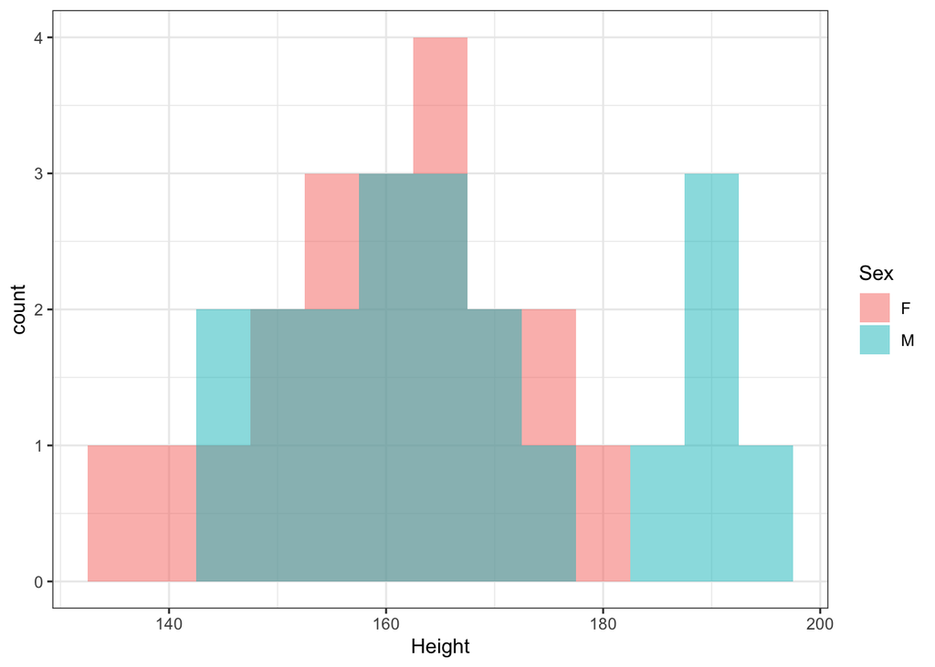

```r
df %>% ggplot(aes(x = Height, fill = Sex))+
  geom_histogram(position = 'identity', binwidth = 5, alpha = .5)+
  theme_bw()
```

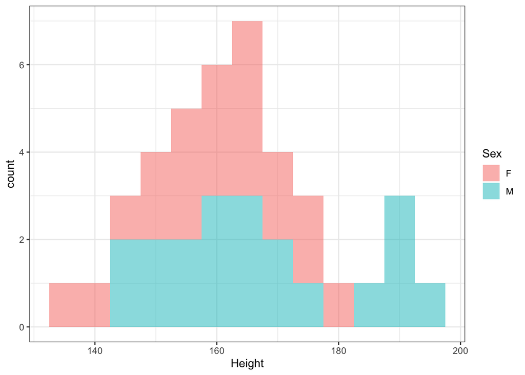

```r
df %>% ggplot(aes(x = Height, fill = Sex))+
  geom_histogram(position = 'stack', binwidth = 5, alpha = .5)+
  theme_bw()
```

Let’s create a boxplot of the Height of Males and Females

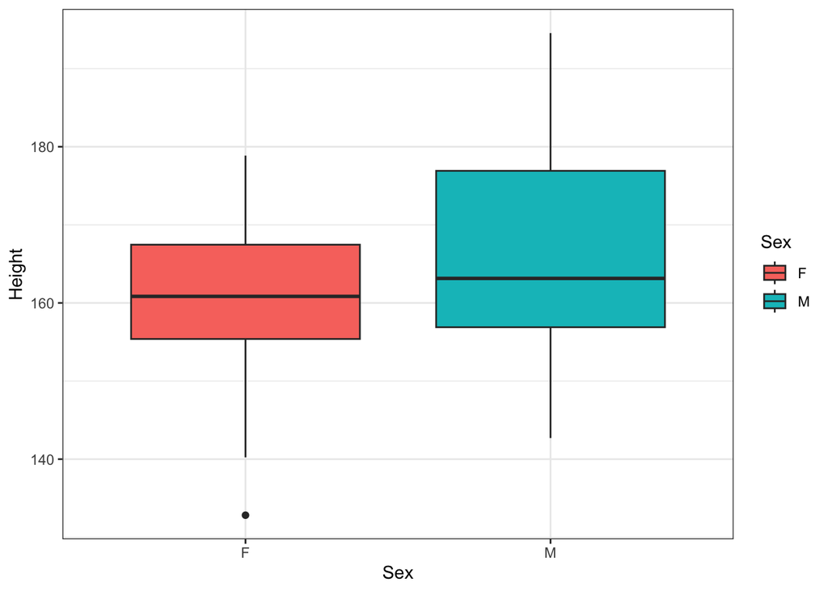

```r
df %>% ggplot(aes(x = Sex, y = Height, fill = Sex))+
  geom_boxplot()+
  theme_bw()
```

Let’s create a jitter plot with a violin plot as background of the Height of Males and Females

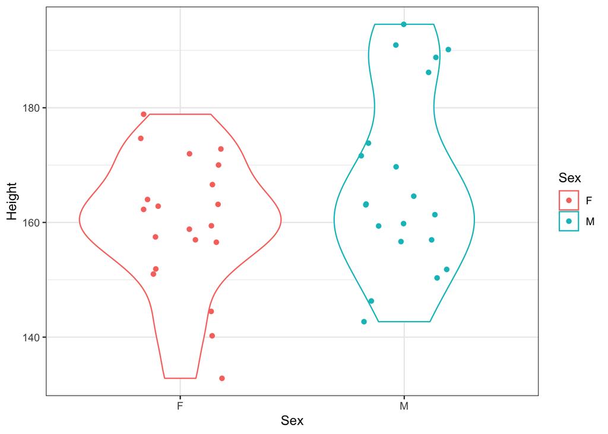

```r
df %>% ggplot(aes(x = Sex, y = Height, color = Sex))+
  geom_violin()+
  geom_jitter(width = .2)+
  theme_bw()
```

Change the labels of the x axis and remove the legend

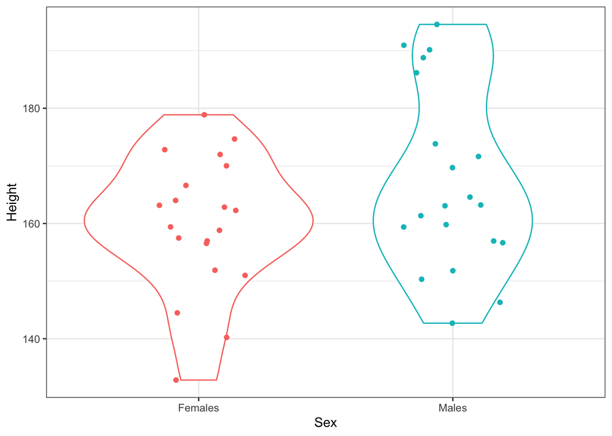

```r
df %>% ggplot(aes(x = Sex, y = Height, color = Sex))+
  geom_violin()+
  geom_jitter(width = .2)+
  scale_x_discrete(breaks = c('F', 'M'), labels = c('Females', 'Males'))+
  theme_bw()+
  theme(legend.position = 'none')
```

# 8 Lists

Generic object that contains different structures (vectors, matrices or data.frames)

```r
B = list(g,h,d, df)
```

# 9 Regular expressions

Sequence of characters (or even one character) that describes a certain pattern found in a text.

Check this website: https://www.datacamp.com/tutorial/regex-r-regular-expressions-guide

- `grep()`, `grepl()` return the indices of strings containing a match (`grep()`) or a logical vector showing which strings contain a match (`grepl()`).
- `gsub()` replace a detected match in each string with a specified string.

Example: Extract the ExcessHet of all positions

```r
vfc_file = read.csv('ColombiaGates_Pvivax_VCF_CH1_CH2.csv')
vfc_file$INFO[1:10]
```

```
##  [1] "AC=1;AF=2.451e-03;AN=408;BaseQRankSum=0.761;ClippingRankSum=-2.450e-01;DP=12359;ExcessHet=3.2330;FS=2.550;InbreedingCoeff=-0.0178;MLEAC=1;MLEAF=2.451e-03;MQ=60.00;MQRankSum=0.489;QD=9.81;ReadPosRankSum=1.77;SOR=0.978;EFF=frameshift_variant(HIGH||aag/aaAg|p.Asn6fs/c.14dupA|114|PVP01_0102600|…
##  [2] "AC=142;AF=0.353;AN=402;BaseQRankSum=-1.420e-01;ClippingRankSum=-5.300e-02;DP=14710;ExcessHet=2147483647.0000;FS=0.000;InbreedingCoeff=-0.5721;MLEAC=141;MLEAF=0.351;MQ=59.97;MQRankSum=0.081;QD=3.57;ReadPosRankSum=-3.580e-01;SOR=0.691;EFF=frameshift_variant(HIGH||aac/Caac|p.Asn35fs/c.102dupC|…
##  [3] "AC=42;AF=0.102;AN=410;BaseQRankSum=-5.350e-01;ClippingRankSum=-4.250e-01;DP=14653;ExcessHet=0.0000;FS=1.890;InbreedingCoeff=0.6720;MLEAC=42;MLEAF=0.102;MQ=59.99;MQRankSum=0.082;QD=22.51;ReadPosRankSum=0.317;SOR=0.561;EFF=missense_variant(MODERATE|MISSENSE|cCc/cAc|p.Pro33His/c.98C>A|114|PVP0…
##  [4] "AC=73,45,67,56,7;AF=0.181,0.111,0.166,0.139,0.017;AN=404;BaseQRankSum=0.283;ClippingRankSum=0.081;DP=18718;ExcessHet=-0.0000;FS=0.000;InbreedingCoeff=0.8071;MLEAC=71,40,66,54,7;MLEAF=0.176,0.099,0.163,0.134,0.017;MQ=59.94;MQRankSum=0.187;QD=37.42;ReadPosRankSum=0.247;SOR=0.644;EFF=conservat…
##  [5] "AC=1;AF=2.488e-03;AN=402;BaseQRankSum=1.77;ClippingRankSum=0.129;DP=18038;ExcessHet=8.6755;FS=6.280;InbreedingCoeff=-0.0557;MLEAC=1;MLEAF=2.488e-03;MQ=58.96;MQRankSum=0.457;QD=2.22;ReadPosRankSum=0.738;SOR=2.240;EFF=missense_variant(MODERATE|MISSENSE|gaG/gaT|p.Glu97Asp/c.291G>T|110|PVP01_01…
##  [6] "AC=8;AF=0.020;AN=408;BaseQRankSum=-4.480e-01;ClippingRankSum=-8.010e-01;DP=15597;ExcessHet=0.0028;FS=0.000;InbreedingCoeff=0.3373;MLEAC=8;MLEAF=0.020;MQ=59.94;MQRankSum=0.410;QD=21.61;ReadPosRankSum=0.417;SOR=0.673;EFF=synonymous_variant(LOW|SILENT|agG/agA|p.Arg45Arg/c.135G>A|110|PVP01_0102…
##  [7] "AC=3;AF=7.109e-03;AN=422;BaseQRankSum=0.814;ClippingRankSum=0.704;DP=49750;ExcessHet=3.9285;FS=0.690;InbreedingCoeff=-0.0221;MLEAC=3;MLEAF=7.109e-03;MQ=59.84;MQRankSum=-3.340e-01;QD=2.97;ReadPosRankSum=0.186;SOR=0.672;EFF=frameshift_variant(HIGH||tta/ttTa|p.Leu9fs/c.26dupT|650|PVP01_0102800…
##  [8] "AC=33;AF=0.079;AN=420;BaseQRankSum=0.145;ClippingRankSum=-3.500e-02;DP=47385;ExcessHet=55.9624;FS=1.413;InbreedingCoeff=-0.2004;MLEAC=32;MLEAF=0.076;MQ=59.91;MQRankSum=-8.900e-02;QD=3.98;ReadPosRankSum=-2.250e-01;SOR=0.679;EFF=frameshift_variant(HIGH||gga/ggGa|p.Ser83fs/c.245dupG|650|PVP01_…
##  [9] "AC=18;AF=0.043;AN=422;BaseQRankSum=0.078;ClippingRankSum=-1.090e-01;DP=47076;ExcessHet=0.0000;FS=3.308;InbreedingCoeff=0.6912;MLEAC=11;MLEAF=0.026;MQ=15.57;MQRankSum=0.109;QD=27.87;ReadPosRankSum=-2.577e+00;SOR=0.923;EFF=conservative_inframe_insertion(MODERATE||agt/TGTGGAGGTGAAACCGAAACGGGAG…
## [10] "AC=7;AF=0.016;AN=426;BaseQRankSum=-4.130e-01;ClippingRankSum=0.743;DP=46244;ExcessHet=0.0025;FS=4.307;InbreedingCoeff=0.3666;MLEAC=7;MLEAF=0.016;MQ=4.96;MQRankSum=1.07;QD=29.26;ReadPosRankSum=1.40;SOR=0.822;EFF=disruptive_inframe_insertion(MODERATE||gga/ggGGAAAGCGGCAGTGGTTCAGGAAGCGGAAGTGGAG…
```